# Rollercoasters EDA

# 1 Introduction

The objective of this report is to explore a rollercoaster dataset. We will be analyzing metrics such as rollercoaster height, speed or material of which the rollercoaster is made out of. We will try to answer some questions concerning the data, such as

1. Who are the top 5 manufacturers by number of rollercoasters?
2. What is the average speed and height of rollercoasters?
3. Are newer rollercoasters faster or taller than older ones?
4. What are the top 10 locations by number of rollercoasters?
5. Do taller rollercoasters tend to be faster?
6. How does the speed, height, or opening amount change over time?

The dataset used for this analysis is sourced from Kaggle (link).

# 2 Data preparation

## 2.1 Importing libraries and data

```r
# Importing the necessary libraries
library(tidyverse)
library(data.table)
library(dplyr)
library(GGally)
library(viridis)
```

```r
# Importing the dataset
raw_data <- read.csv("coaster_db.csv")

# Setting the option for size of plots
options(repr.plot.width = 16, repr.plot.height = 9)

my_colors <- c(
    "Steel" = "#108dc7",
    "Wood" = "#ef8e38",
    "Other" = "#DBDBDB"
)

my_theme <- theme(
  axis.text = element_text(size = 16),  # Axis tick labels
  axis.title = element_text(size = 24),  # Axis titles
  plot.title = element_text(size = 24, face = "bold"),  # Plot title
  legend.text = element_text(size = 16),  # Legend text
  legend.title = element_text(size = 16)  # Legend title
)
```

## 2.2 Understanding the data

```r
# Checking the dataset dimensions
dim(raw_data)
```

```
## [1] 1087   56
```

```r
# Checking the dataset column names
colnames(raw_data)
```

```
##  [1] "coaster_name"                  "Length"
##  [3] "Speed"                         "Location"
##  [5] "Status"                        "Opening.date"
##  [7] "Type"                          "Manufacturer"
##  [9] "Height.restriction"            "Model"
## [11] "Height"                        "Inversions"
## [13] "Lift.launch.system"            "Cost"
## [15] "Trains"                        "Park.section"
## [17] "Duration"                      "Capacity"
## [19] "G.force"                       "Designer"
## [21] "Max.vertical.angle"            "Drop"
## [23] "Soft.opening.date"             "Fast.Lane.available"
## [25] "Replaced"                      "Track.layout"
## [27] "Fastrack.available"            "Soft.opening.date.1"
## [29] "Closing.date"                  "Opened"
## [31] "Replaced.by"                   "Website"
## [33] "Flash.Pass.Available"          "Must.transfer.from.wheelchair"
## [35] "Theme"                         "Single.rider.line.available"
## [37] "Restraint.Style"               "Flash.Pass.available"
## [39] "Acceleration"                  "Restraints"
## [41] "Name"                          "year_introduced"
## [43] "latitude"                      "longitude"
## [45] "Type_Main"                     "opening_date_clean"
## [47] "speed1"                        "speed2"
## [49] "speed1_value"                  "speed1_unit"
## [51] "speed_mph"                     "height_value"
## [53] "height_unit"                   "height_ft"
## [55] "Inversions_clean"              "Gforce_clean"
```

```r
# Checking the dataset head
head(raw_data)
```

|  | coaster_name | Length | Speed | Location | Status | Opening.date | Type | Manufacturer | Height.restriction | Model | Height | Inversions | Lift.launch.system | Cost | Trains | Park.section | Duration | Capacity | G.force | Designer | Max.vertical.angle | Drop | Soft.opening.date | Fast.Lane.available | Replaced | Track.layout | Fastrack.available | Soft.opening.date.1 | Closing.date | … |
| --- | --- | --- | --- | --- | --- | --- | --- | --- | --- | --- | --- | --- | --- | --- | --- | --- | --- | --- | --- | --- | --- | --- | --- | --- | --- | --- | --- | --- | --- | --- |
| 1 | Switchback Railway | 600 ft (180 m) | 6 mph (9.7 km/h) | Coney Island | Removed | June 16, 1884 | Wood | LaMarcus Adna Thompson |  | Lift Packed | 50 ft (15 m) | NA | gravity |  |  | Coney Island Cyclone Site | 1:00 | 1600 riders per hour | 2.9 | LaMarcus Adna Thompson | 30° | 43 ft (13 m) |  |  |  | Gravity pulled coaster |  |  |  | … |
| 2 | Flip Flap Railway |  |  | Sea Lion Park | Removed | 1895 | Wood | Lina Beecher |  |  |  | 1 |  |  | a single car. Riders are arranged 1 across in 2 rows for a total of 2 riders per train. |  |  |  | 12 | Lina Beecher |  |  |  |  |  |  |  |  | 1902 | … |
| 3 | Switchback Railway (Euclid Beach Park) |  |  | Cleveland, Ohio, United States | Closed |  | Other |  |  |  |  | NA |  |  |  |  |  |  |  |  |  |  |  |  |  |  |  |  |  | … |
| 4 | Loop the Loop (Coney Island) |  |  | Other | Removed | 1901 | Steel | Edwin Prescott |  |  |  | 1 |  |  | a single car. Riders are arranged 2 across in 2 rows for a total of 4 riders per train. |  |  |  |  | Edward A. Green |  |  |  |  | Switchback Railway |  |  |  | 1910 | … |
| 5 | Loop the Loop (Young's Pier) |  |  | Other | Removed | 1901 | Steel | Edwin Prescott |  |  |  | 1 |  |  |  |  |  |  |  | Edward A. Green |  |  |  |  |  |  |  |  | 1912 | … |
| 6 | Cannon Coaster |  |  | Coney Island | Removed | 1902 | Wood | George Francis Meyer |  |  | 40 ft (12 m) | NA |  |  |  |  |  |  |  |  |  |  |  |  |  |  |  |  | 1907 | … |

```r
# Checking the dataset tail
tail(raw_data)
```

|  | coaster_name | Length | Speed | Location | Status | Opening.date | Type | Manufacturer | Height.restriction | Model | Height | Inversions | Lift.launch.system | Cost | Trains | Park.section | Duration | Capacity | G.force | Designer | Max.vertical.angle | Drop | Soft.opening.date | Fast.Lane.available | Replaced | Track.layout | Fastrack.available | Soft.opening.date.1 | Closing.date | … |
| --- | --- | --- | --- | --- | --- | --- | --- | --- | --- | --- | --- | --- | --- | --- | --- | --- | --- | --- | --- | --- | --- | --- | --- | --- | --- | --- | --- | --- | --- | --- |
| 1082 | Leviathan (Sea World) | 1,000.0 m (3,280.8 ft) | 80.0 km/h (49.7 mph) | Sea World | Under construction | Easter 2022 | Wood | Martin & Vleminckx |  |  | 32 m (105 ft) | 0 | Chain lift hill | $20,000,000[1] | 2 trains with 12 cars. Riders are arranged 2 across in a single row for a total of 24 riders per train. | The New Atlantis |  | 720 riders per hour |  | The Gravity Group |  |  |  |  |  | Twister |  |  |  | … |
| 1083 | American Dreier Looping | 3,444 ft (1,050 m) | 53 mph (85 km/h) | Other |  |  | Steel | Anton Schwarzkopf | 55 in (140 cm) |  | 111 ft (34 m) | 3 | Booster Wheel Lift Hill |  | 3 trains with 5 cars. Riders are arranged 2 across in 2 rows for a total of 20 riders per train. |  |  | 1,500 riders per hour | 4.7 | Werner Stengel |  |  |  |  |  |  |  |  |  | … |
| 1084 | Pantheon (roller coaster) | 3,328 ft (1,014 m) | 73 mph (117 km/h) | Busch Gardens Williamsburg | Under construction | 2022 | Steel – Launched | Intamin |  | Blitz Coaster | 178 ft (54 m) | 2 | LSM |  | 2 trains with 5 cars. Riders are arranged 2 across in 2 rows for a total of 20 riders per train. |  |  |  |  |  | 95° |  |  |  |  |  |  |  |  | … |
| 1085 | Tron Lightcycle Power Run | 3,169.3 ft (966.0 m) | 59.3[1] mph (95.4 km/h) | Other |  | June 16, 2016 | Steel – Launched | Vekoma | 4[2] ft (122 cm) | Motorbike roller coaster | 78.1 ft (23.8 m) | 0 | LIM Launch |  | 7 trains with 7 cars. Riders are arranged 2 across in a single row for a total of 14 riders per train. |  | ~2:00 | 1,680 riders per hour | 4 | Walt Disney Imagineering |  |  |  |  |  |  |  |  |  | … |
| 1086 | Tumbili | 770 ft (230 m) | 34 mph (55 km/h) | Kings Dominion | Under construction |  | Steel – 4th Dimension – Wing Coaster | S&S – Sansei Technologies |  | 4D Free Spin | 112 ft (34 m) | 0 | Vertical chain lift hill |  | Single car trains with riders arranged 4 across in 2 rows for a total of 8 riders per train | Jungle X-Pedition | 0:55 |  |  |  |  |  |  |  | The Crypt |  |  |  |  | … |
| 1087 | Wonder Woman Flight of Courage | 3,300 ft (1,000 m) | 58 mph (93 km/h) | Six Flags Magic Mountain | Under construction | 2022 | Steel – Single-rail | Rocky Mountain Construction |  | Raptor – Custom | 131 ft (40 m) | 3 | Chain lift hill |  |  | DC Universe |  |  |  |  | 87° | 127 ft (39 m) |  |  | Green Lantern: First Flight Tidal Wave |  |  |  |  | … |

## 2.3 Preparing the data

```r
# Selecting only the relevant columns
df <- raw_data %>%
  select(
    coaster_name, Location, Status, Type_Main, Manufacturer,
    speed_mph, height_value, height_unit, Inversions_clean, Gforce_clean,
    opening_date_clean
  )

# Checking the updated dataframe
head(df)
```

|  | coaster_name | Location | Status | Type_Main | Manufacturer | speed_mph | height_value | height_unit | Inversions_clean | Gforce_clean | opening_date_clean |
| --- | --- | --- | --- | --- | --- | --- | --- | --- | --- | --- | --- |
| 1 | Switchback Railway | Coney Island | Removed | Wood | LaMarcus Adna Thompson | 6 | 50 | ft | 0 | 2.9 | 1884-06-16 |
| 2 | Flip Flap Railway | Sea Lion Park | Removed | Wood | Lina Beecher | NA | NA |  | 1 | 12.0 | 1895-01-01 |
| 3 | Switchback Railway (Euclid Beach Park) | Cleveland, Ohio, United States | Closed | Other |  | NA | NA |  | 0 | NA |  |
| 4 | Loop the Loop (Coney Island) | Other | Removed | Steel | Edwin Prescott | NA | NA |  | 1 | NA | 1901-01-01 |
| 5 | Loop the Loop (Young's Pier) | Other | Removed | Steel | Edwin Prescott | NA | NA |  | 1 | NA | 1901-01-01 |
| 6 | Cannon Coaster | Coney Island | Removed | Wood | George Francis Meyer | NA | 40 | ft | 0 | NA | 1902-01-01 |

```r
# Creating a new unified height column
df <- df %>%
  mutate(
    Height_unified = ifelse(
      height_unit == "m",
      height_value * 3.28084,  # Convert meters to feet
      height_value             # Keep feet as is
    )
  )
```

```r
# Dropping unnecessary columns
df <- df %>%
  select(-height_value, -height_unit)
```

```r
# Renaming columns
df <- df %>%
  rename(
    Name = coaster_name,
    Material = Type_Main,
    Speed_mph = speed_mph,
    Height_ft = Height_unified,
    Inversions = Inversions_clean,
    Gforce = Gforce_clean,
    Opening_date = opening_date_clean
  )

# Checking the updated dataframe
head(df)
```

|  | Name | Location | Status | Material | Manufacturer | Speed_mph | Inversions | Gforce | Opening_date | Height_ft |
| --- | --- | --- | --- | --- | --- | --- | --- | --- | --- | --- |
| 1 | Switchback Railway | Coney Island | Removed | Wood | LaMarcus Adna Thompson | 6 | 0 | 2.9 | 1884-06-16 | 50 |
| 2 | Flip Flap Railway | Sea Lion Park | Removed | Wood | Lina Beecher | NA | 1 | 12.0 | 1895-01-01 | NA |
| 3 | Switchback Railway (Euclid Beach Park) | Cleveland, Ohio, United States | Closed | Other |  | NA | 0 | NA |  | NA |
| 4 | Loop the Loop (Coney Island) | Other | Removed | Steel | Edwin Prescott | NA | 1 | NA | 1901-01-01 | NA |
| 5 | Loop the Loop (Young's Pier) | Other | Removed | Steel | Edwin Prescott | NA | 1 | NA | 1901-01-01 | NA |
| 6 | Cannon Coaster | Coney Island | Removed | Wood | George Francis Meyer | NA | 0 | NA | 1902-01-01 | 40 |

```r
# Checking the structure of the dataset
str(df)
```

```
## 'data.frame':    1087 obs. of  10 variables:
##  $ Name        : chr  "Switchback Railway" "Flip Flap Railway" "Switchback Railway (Euclid Beach Park)" "Loop the Loop (Coney Island)" ...
##  $ Location    : chr  "Coney Island" "Sea Lion Park" "Cleveland, Ohio, United States" "Other" ...
##  $ Status      : chr  "Removed" "Removed" "Closed" "Removed" ...
##  $ Material    : chr  "Wood" "Wood" "Other" "Steel" ...
##  $ Manufacturer: chr  "LaMarcus Adna Thompson" "Lina Beecher" "" "Edwin Prescott" ...
##  $ Speed_mph   : num  6 NA NA NA NA NA 10 NA NA NA ...
##  $ Inversions  : int  0 1 0 1 1 0 0 0 0 0 ...
##  $ Gforce      : num  2.9 12 NA NA NA NA NA NA NA NA ...
##  $ Opening_date: chr  "1884-06-16" "1895-01-01" "" "1901-01-01" ...
##  $ Height_ft   : num  50 NA NA NA NA 40 41 NA 60 NA ...
```

```r
# Converting `Opening_date` to Date type
df$Opening_date <- as.Date(df$Opening_date, format = "%Y-%m-%d")
```

```r
# Extract year from Opening_date
df <- df %>%
  mutate(Opening_year = as.numeric(format(Opening_date, "%Y")))
```

```r
# Summarizing basic descriptive statistics
summary(df)
```

```
##      Name             Location            Status            Material
##  Length:1087        Length:1087        Length:1087        Length:1087
##  Class :character   Class :character   Class :character   Class :character
##  Mode  :character   Mode  :character   Mode  :character   Mode  :character
##
##
##
##
##  Manufacturer         Speed_mph        Inversions         Gforce
##  Length:1087        Min.   :  5.00   Min.   : 0.000   Min.   : 0.800
##  Class :character   1st Qu.: 37.30   1st Qu.: 0.000   1st Qu.: 3.400
##  Mode  :character   Median : 49.70   Median : 0.000   Median : 4.000
##                     Mean   : 48.62   Mean   : 1.327   Mean   : 3.824
##                     3rd Qu.: 58.00   3rd Qu.: 2.000   3rd Qu.: 4.500
##                     Max.   :149.10   Max.   :14.000   Max.   :12.000
##                     NA's   :150                       NA's   :725
##   Opening_date          Height_ft       Opening_year
##  Min.   :1884-06-16   Min.   :   8.0   Min.   :1884
##  1st Qu.:1987-06-07   1st Qu.:  56.0   1st Qu.:1987
##  Median :2000-04-22   Median :  92.0   Median :2000
##  Mean   :1994-07-25   Mean   : 102.1   Mean   :1994
##  3rd Qu.:2010-11-04   3rd Qu.: 120.0   3rd Qu.:2010
##  Max.   :2022-03-01   Max.   :3937.0   Max.   :2022
##  NA's   :250          NA's   :122      NA's   :250
```

```r
# Replacing empty strings with NA in all character columns
df <- df %>%
  mutate(across(where(is.character), ~ ifelse(. == "", NA, .)))

# Checking the result
head(df)
```

|  | Name | Location | Status | Material | Manufacturer | Speed_mph | Inversions | Gforce | Opening_date | Height_ft | Opening_year |
| --- | --- | --- | --- | --- | --- | --- | --- | --- | --- | --- | --- |
| 1 | Switchback Railway | Coney Island | Removed | Wood | LaMarcus Adna Thompson | 6 | 0 | 2.9 | 1884-06-16 | 50 | 1884 |
| 2 | Flip Flap Railway | Sea Lion Park | Removed | Wood | Lina Beecher | NA | 1 | 12.0 | 1895-01-01 | NA | 1895 |
| 3 | Switchback Railway (Euclid Beach Park) | Cleveland, Ohio, United States | Closed | Other | NA | NA | 0 | NA |  | NA | NA |
| 4 | Loop the Loop (Coney Island) | Other | Removed | Steel | Edwin Prescott | NA | 1 | NA | 1901-01-01 | NA | 1901 |
| 5 | Loop the Loop (Young's Pier) | Other | Removed | Steel | Edwin Prescott | NA | 1 | NA | 1901-01-01 | NA | 1901 |
| 6 | Cannon Coaster | Coney Island | Removed | Wood | George Francis Meyer | NA | 0 | NA | 1902-01-01 | 40 | 1902 |

```r
# Checking for missing values in each column
colSums(is.na(df))
```

```
##         Name     Location       Status     Material Manufacturer    Speed_mph
##            0            0          213            0           59          150
##   Inversions       Gforce Opening_date    Height_ft Opening_year
##            0          725          250          122          250
```

```r
# Replacing NA in Status and Manufacturer with "Unknown"
df <- df %>%
  mutate(
    Status = ifelse(is.na(Status), "Unknown", Status),
    Manufacturer = ifelse(is.na(Manufacturer), "Unknown", Manufacturer)
  )
```

```r
# Dropping the Gforce column
df <- df %>%
  select(-Gforce)
```

```r
# Checking for missing values
colSums(is.na(df))
```

```
##         Name     Location       Status     Material Manufacturer    Speed_mph
##            0            0            0            0            0          150
##   Inversions Opening_date    Height_ft Opening_year
##            0          250          122          250
```

```r
# Imputating missing speed_mph with the median
df <- df %>%
  mutate(Speed_mph = ifelse(is.na(Speed_mph), median(Speed_mph, na.rm = TRUE), Speed_mph))

# Imputating missing height_ft with the median
df <- df %>%
  mutate(Height_ft = ifelse(is.na(Height_ft), median(Height_ft, na.rm = TRUE), Height_ft))

# Checking for missing values
colSums(is.na(df))
```

```
##         Name     Location       Status     Material Manufacturer    Speed_mph
##            0            0            0            0            0            0
##   Inversions Opening_date    Height_ft Opening_year
##            0          250            0          250
```

```r
# Removing rows with height_ft > 500 feet
df <- df %>%
  filter(Height_ft <= 500)
```

# 3 Exploratory data analysis

## 3.1 Basic univariate analysis

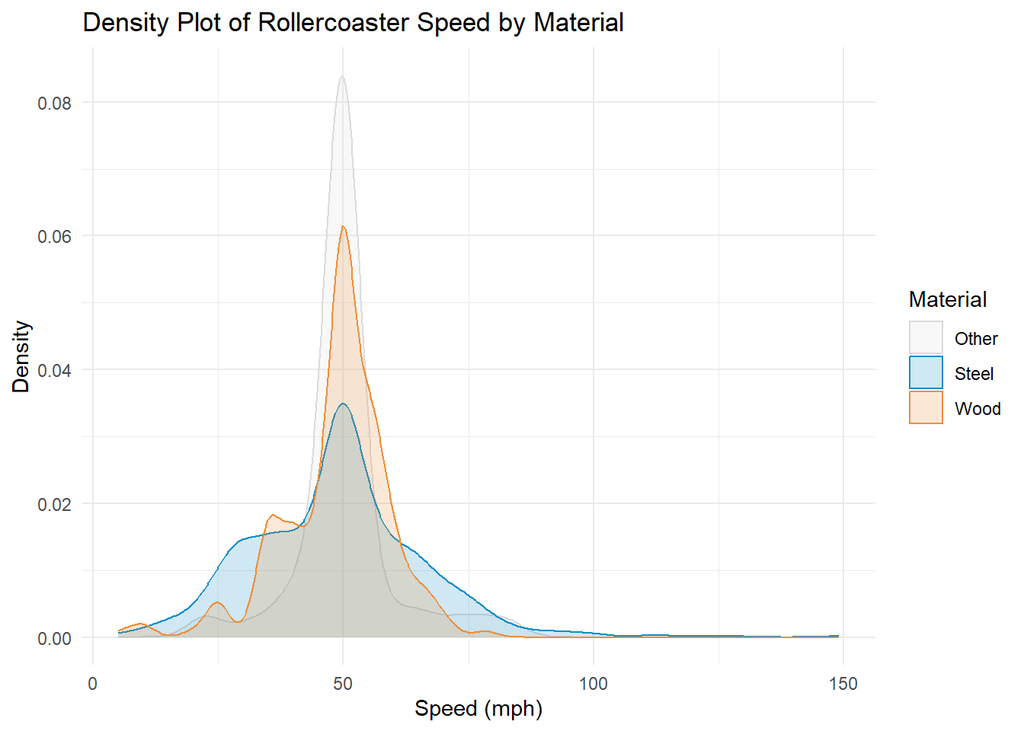

```r
# Density plot for Speed
ggplot(df, aes(Speed_mph)) +
    geom_density(alpha = 0.2, aes(fill = Material, colour = Material)) +
    scale_fill_manual(values = my_colors) +
    scale_color_manual(values = my_colors) +
    labs(
        title = "Density Plot of Rollercoaster Speed by Material",
        x = "Speed (mph)",
        y = "Density"
    ) +
    theme_minimal()
```

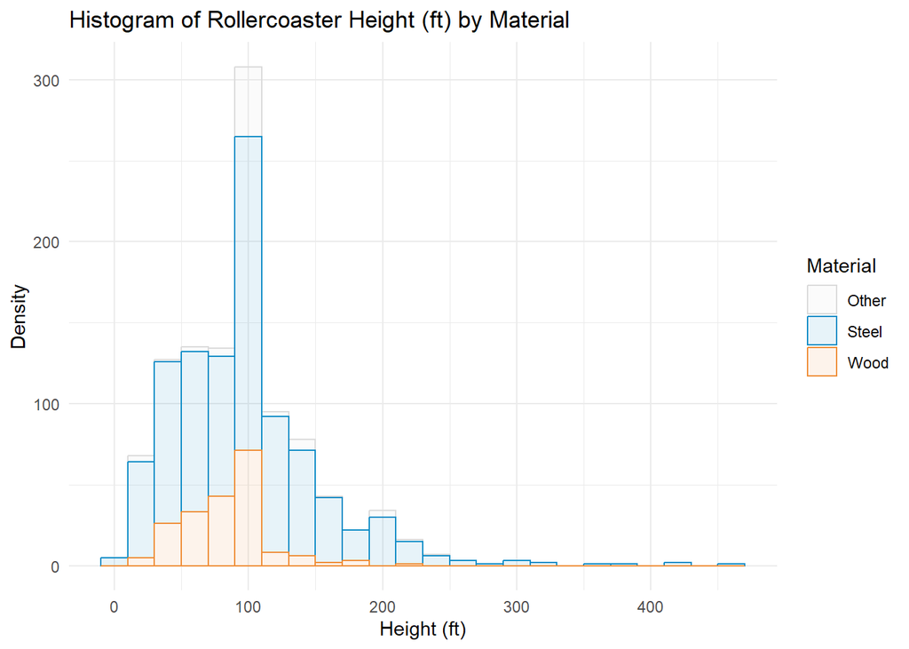

```r
# Histogram of speed
ggplot(df, aes(Height_ft)) +
    geom_histogram(alpha = 0.1, binwidth = 20, aes(fill = Material, colour = Material)) +
    scale_fill_manual(values = my_colors) +
    scale_color_manual(values = my_colors) +
    labs(
        title = "Histogram of Rollercoaster Height (ft) by Material",
        x = "Height (ft)",
        y = "Density"
    ) +
    theme_minimal()
```

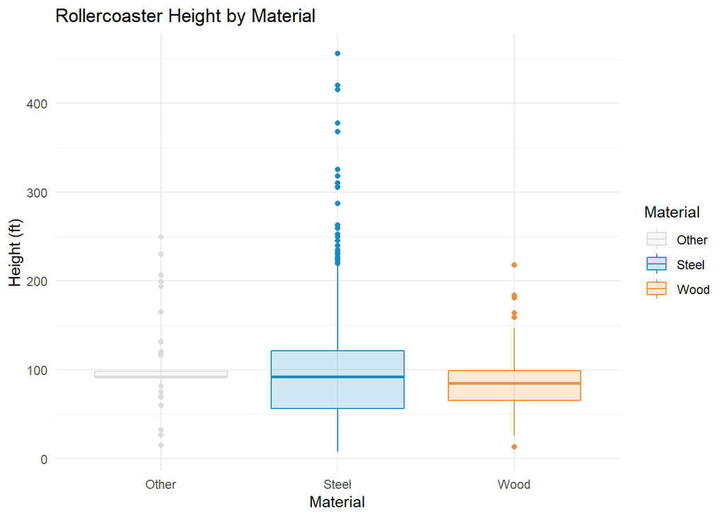

```r
# Boxplot of Height by Material
ggplot(df, aes(x = Material, y = Height_ft, fill = Material, colour = Material)) +
    geom_boxplot() +
    scale_fill_manual(values = alpha(my_colors, 0.2)) +
    scale_color_manual(values = my_colors) +
    labs(
        title = "Rollercoaster Height by Material",
        x = "Material",
        y = "Height (ft)"
    ) +
    theme_minimal()
```

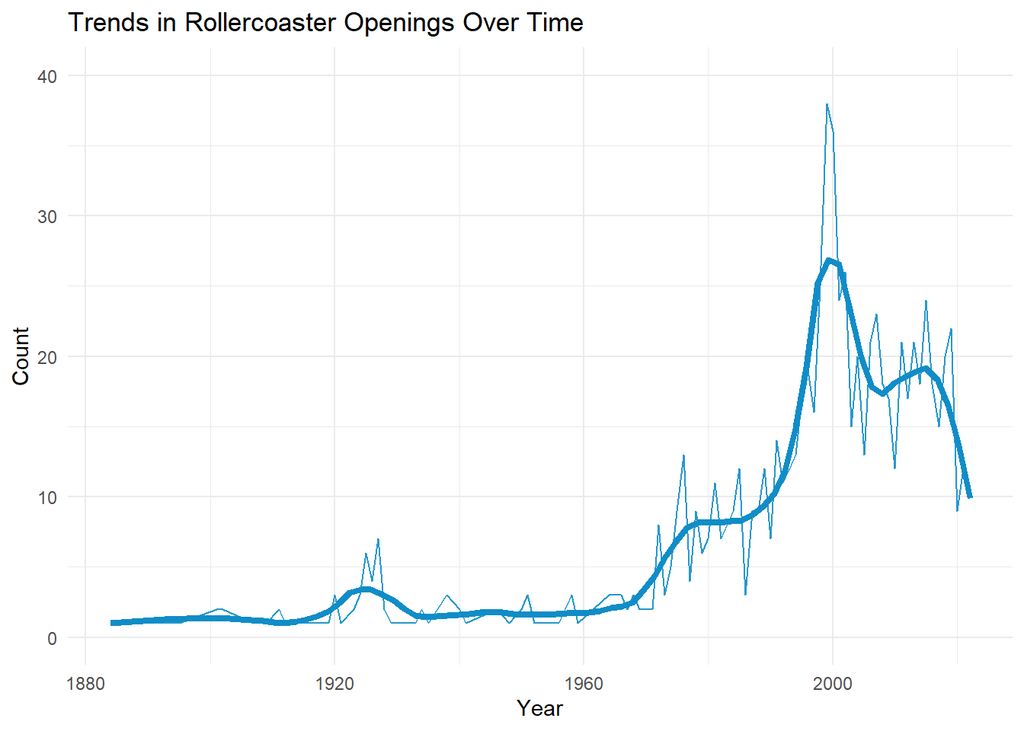

```r
# Line Plot of Trends Over Time
df %>% count(Opening_year) %>%
    ggplot(aes(x = Opening_year, y = n)) +
    ylim(0, 40) +
    geom_line(color = "#108dc7", size = 0.5, alpha = 0.9, na.rm = TRUE) +
    geom_smooth(method = "loess", formula = "y ~ x", se = FALSE, color = "#108dc7", size = 1.5, span = 0.2, na.rm = TRUE) +
    labs(
      title = "Trends in Rollercoaster Openings Over Time",
      x = "Year",
      y = "Count"
    ) +
    theme_minimal()
```

## 3.2 Basic multivariate analysis

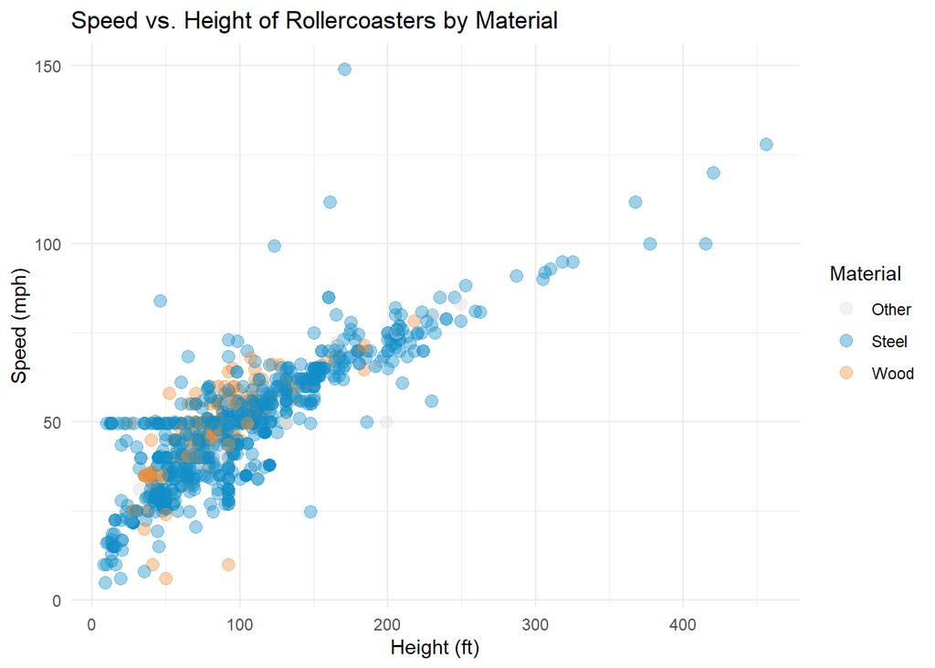

```r
# Scatterplot: Speed vs. Height
ggplot(df, aes(x = Height_ft, y = Speed_mph)) +
    geom_point(alpha = 0.4, size = 3, aes(fill = Material, colour = Material)) +
    scale_fill_manual(values = my_colors) +
    scale_color_manual(values = my_colors) +
    labs(
    title = "Speed vs. Height of Rollercoasters by Material",
        x = "Height (ft)",
        y = "Speed (mph)"
    ) +
    theme_minimal()
```

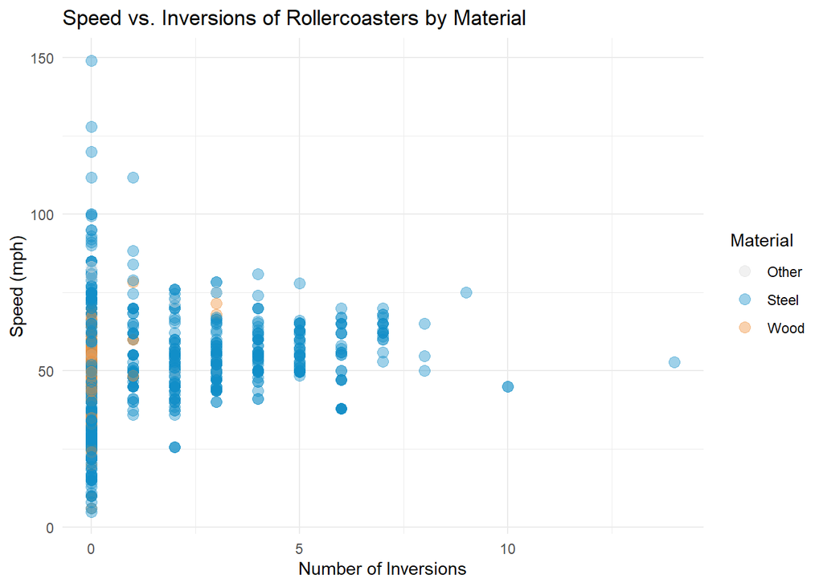

```r
# Scatterplot: Speed vs. Inversions
ggplot(df, aes(x = Inversions, y = Speed_mph)) +
    geom_point(alpha = 0.4, size = 3, aes(fill = Material, colour = Material)) +
    scale_fill_manual(values = my_colors) +
    scale_color_manual(values = my_colors) +
    labs(
    title = "Speed vs. Inversions of Rollercoasters by Material",
        x = "Number of Inversions",
        y = "Speed (mph)"
    ) +
    theme_minimal()
```

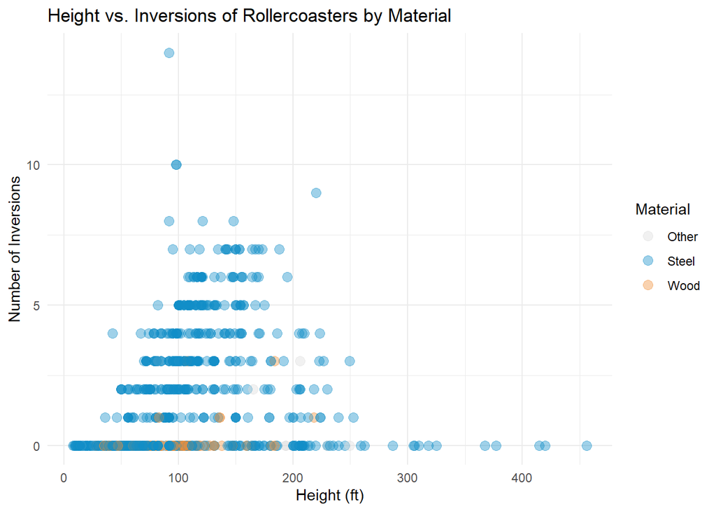

```r
# Scatterplot: Height vs. Inversions
ggplot(df, aes(x = Height_ft, y = Inversions)) +
    geom_point(alpha = 0.4, size = 3, aes(fill = Material, colour = Material)) +
    scale_fill_manual(values = my_colors) +
    scale_color_manual(values = my_colors) +
    labs(
    title = "Height vs. Inversions of Rollercoasters by Material",
        x = "Height (ft)",
        y = "Number of Inversions"
    ) +
    theme_minimal()
```

# 4 Key findings

## 4.1 Who are the top 5 manufacturers by number of rollercoasters?

```r
# Top 5 manufacturers by number of rollercoasters
top_manufacturers <- df %>%
  group_by(Manufacturer) %>%
  summarise(Count = n()) %>%
  arrange(desc(Count)) %>%
  head(5)

# View the result
top_manufacturers
```

| Manufacturer | Count |
| --- | --- |
| Vekoma | 135 |
| Bolliger & Mabillard | 119 |
| Intamin | 99 |
| Mack Rides | 62 |
| Unknown | 59 |

## 4.2 What is the average speed and height of rollercoasters?

```r
# Average speed and height
avg_speed <- mean(df$Speed_mph, na.rm = TRUE)
avg_height <- mean(df$Height_ft, na.rm = TRUE)

# View the results
cat("Average Speed:", round(avg_speed, 2), "mph\n")
```

```
## Average Speed: 48.79 mph
```

```r
cat("Average Height:", round(avg_height, 2), "ft\n")
```

```
## Average Height: 97.47 ft
```

## 4.3 Are newer rollercoasters faster or taller than older ones?

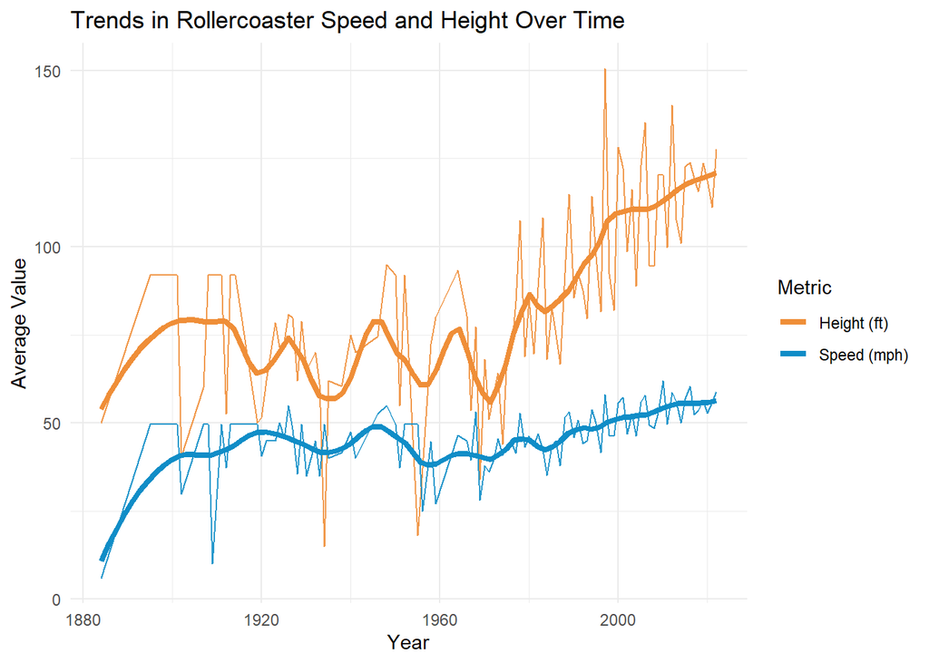

```r
# Trends over time
trends_over_time <- df %>%
  group_by(Opening_year) %>%
  summarise(
    Avg_Speed = mean(Speed_mph, na.rm = TRUE),
    Avg_Height = mean(Height_ft, na.rm = TRUE),
    Count = n()
  )

# Reshaping the data into long format
trends_over_time_long <- trends_over_time %>%
    pivot_longer(
        cols = c(Avg_Speed, Avg_Height),
        names_to = "Metric",
        values_to = "Value"
    )

# Plotting trends with a color legend
ggplot(trends_over_time_long, aes(x = Opening_year)) +
    geom_line(aes(y = Value, color = Metric), alpha = 0.9, size = 0.5, na.rm = TRUE) +
    geom_smooth(aes(y = Value, color = Metric), method = "loess", formula = "y ~ x", se = FALSE, size = 1.5, span = 0.2, na.rm = TRUE) +
    scale_color_manual(
        values = c("Avg_Speed" = "#108dc7", "Avg_Height" = "#ef8e38"),
        labels = c("Avg_Speed" = "Speed (mph)", "Avg_Height" = "Height (ft)")
    ) +
    labs(
        title = "Trends in Rollercoaster Speed and Height Over Time",
        x = "Year",
        y = "Average Value",
        color = "Metric"
    ) +
    theme_minimal()
```

As we can clearly see from the plot, there is a positive trend in rollercoasters becoming faster and higher over time.

## 4.4 What are the top 10 locations by number of rollercoasters?

```r
# Top 10 locations by number of rollercoasters
top_locations <- df %>%
    filter(Location != "Other") %>%
    group_by(Location) %>%
    summarise(Count = n()) %>%
    arrange(desc(Count)) %>%
    head(10)

# View the result
top_locations
```

| Location | Count |
| --- | --- |
| Cedar Point | 19 |
| Kings Island | 19 |
| Six Flags Magic Mountain | 17 |
| Hersheypark | 16 |
| Carowinds | 15 |
| Six Flags Great Adventure | 15 |
| Canada's Wonderland | 14 |
| Alton Towers | 13 |
| Busch Gardens Williamsburg | 12 |
| Kings Dominion | 12 |

## 4.5 Do taller rollercoasters tend to be faster?

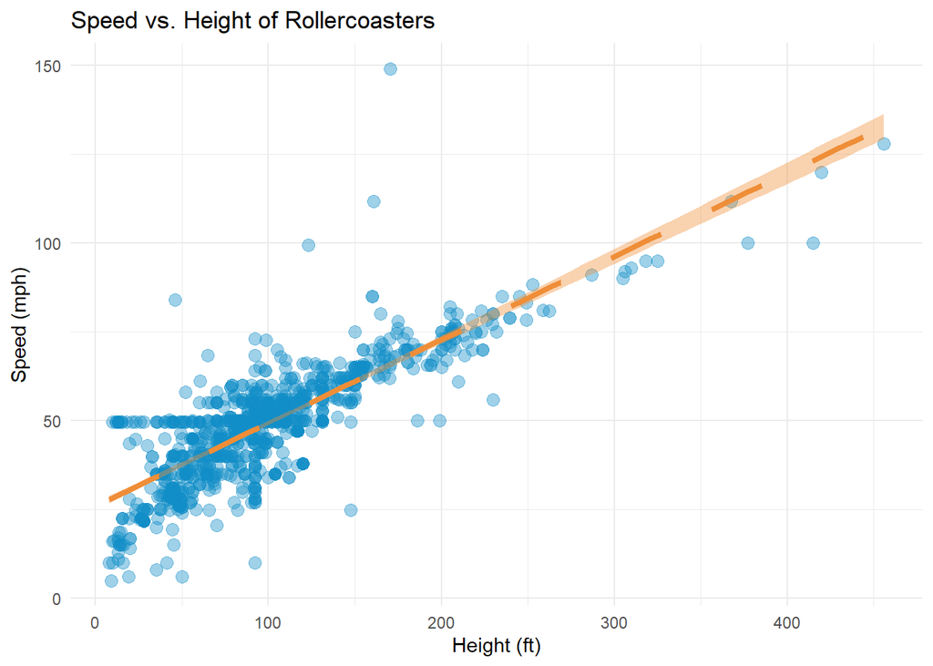

```r
# Scatterplot: Speed vs. Height
ggplot(df, aes(x = Height_ft, y = Speed_mph)) +
    geom_point(alpha = 0.4, size = 3, color = "#108dc7") +
    geom_smooth(method = "lm", formula = "y ~ x", se = TRUE, color = "#ef8e38", fill = "#ef8e38", size = 1.5, linetype = "aa") +
    labs(
    title = "Speed vs. Height of Rollercoasters",
        x = "Height (ft)",
        y = "Speed (mph)"
    ) +
    theme_minimal()
```

```r
# Correlation coefficient
cat("Correlation coefficient:", round(cor(df$Height_ft, df$Speed_mph, use = "complete.obs"), 2))
```

```
## Correlation coefficient: 0.82
```

Yes, the correlation is very strong.

## 4.6 How does the amount of rollercoaster openings change over time?

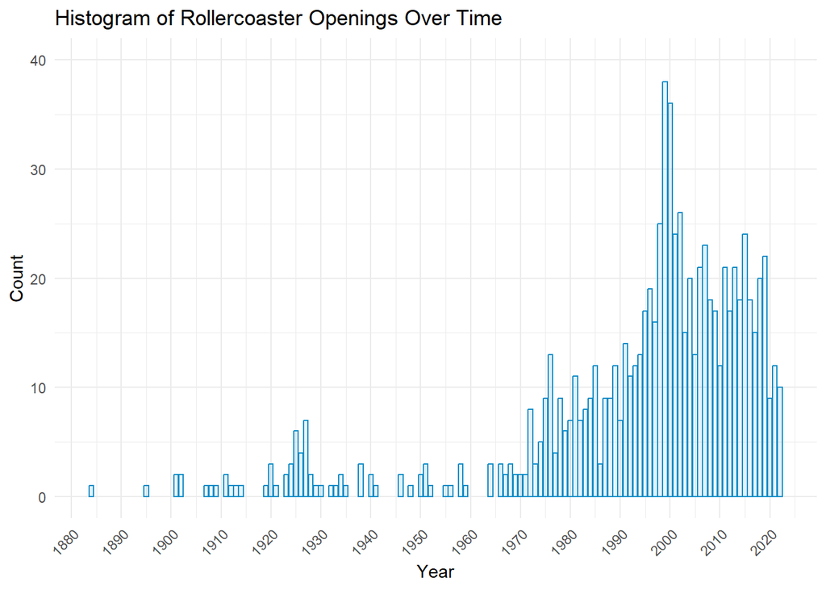

```r
# Bar chart of Rollercoaster Openings Over Time
ggplot(df, aes(x = Opening_year)) +
    geom_bar(, color = "#108dc7", fill = "#108dc7", alpha = 0.1, na.rm = TRUE) +
    scale_x_continuous(
        breaks = seq(1880, 2025, by = 10),
        labels = seq(1880, 2025, by = 10)
    ) +
    labs(
        title = "Histogram of Rollercoaster Openings Over Time",
        x = "Year",
        y = "Count"
        ) +
    ylim(0, 40) +
    theme_minimal() +
    theme(axis.text.x = element_text(angle = 45, hjust = 1))
```

As we can see from the plot, there was a peak around year 2000 and from that time there is a slight negative trend.